# Course Project: Reproducible Research

Aayush Vyas

23/04/2020

## Instructions for Assignment

1. Code for reading in the dataset and/or processing the data
2. Histogram of the total number of steps taken each day
3. Mean and median number of steps taken each day
4. Time series plot of the average number of steps taken
5. The 5-minute interval that, on average, contains the maximum number of steps
6. Code to describe and show a strategy for imputing missing data
7. Histogram of the total number of steps taken each day after missing values are imputed
8. Panel plot comparing the average number of steps taken per 5-minute interval across weekdays and weekends
9. All of the R code needed to reproduce the results (numbers, plots, etc.) in the report

## Code for reading in the dataset and/or processing the data

First, will start with loading libraries which will be required later.

```r
library(ggplot2)
library(gridExtra)
```

After loading the required libraries, dowloading the data from the given url in the curent working directory and unzipping the downloaded file. The data is then read and stored as a data frame in a variable ‘df’.

```r
url <- "https://d396qusza40orc.cloudfront.net/repdata%2Fdata%2Factivity.zip"
download.file(url, "Assignment_Data.zip")
unzip("Assignment_Data.zip")

df <- read.csv("activity.csv", stringsAsFactors = FALSE)
```

Exploring the basics of data.

```r
str(df)
```

```
## 'data.frame':    17568 obs. of  3 variables:
##  $ steps   : int  NA NA NA NA NA NA NA NA NA NA ...
##  $ date    : chr  "2012-10-01" "2012-10-01" "2012-10-01" "2012-10-01" ...
##  $ interval: int  0 5 10 15 20 25 30 35 40 45 ...
```

Here, it can be seen that column containing dates is readed as character strings. Therefore, changing it’s data type to dates.

```r
df$date <- as.Date(df$date)
str(df)
```

```
## 'data.frame':    17568 obs. of  3 variables:
##  $ steps   : int  NA NA NA NA NA NA NA NA NA NA ...
##  $ date    : Date, format: "2012-10-01" "2012-10-01" "2012-10-01" ...
##  $ interval: int  0 5 10 15 20 25 30 35 40 45 ...
```

Looking few entries of df.

```r
head(df)
```

```
##   steps       date interval
## 1    NA 2012-10-01        0
## 2    NA 2012-10-01        5
## 3    NA 2012-10-01       10
## 4    NA 2012-10-01       15
## 5    NA 2012-10-01       20
## 6    NA 2012-10-01       25
```

## Histogram of the total number of steps taken each day

Subsetting the original dataset to dataset only containing total steps taken each day, and corresponding date and storing it in a variable ‘stepseachday’

```r
stepseachday <- aggregate(steps ~ date, df, sum, na.rm = TRUE)
```

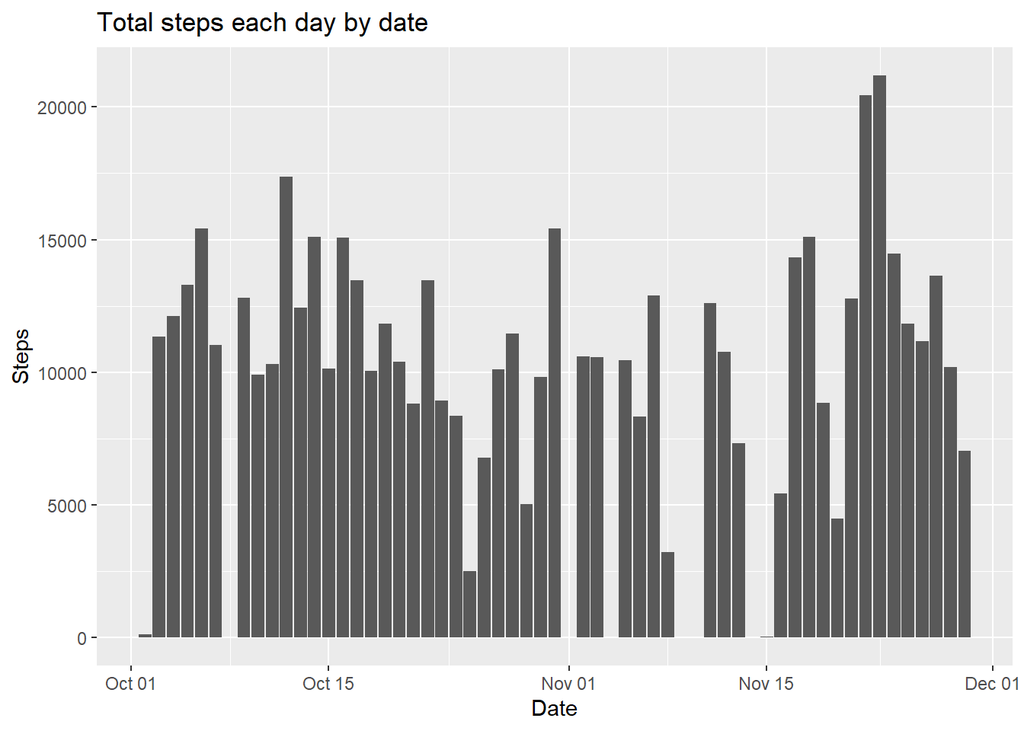

```r
g1 <- ggplot(stepseachday, aes(date, steps)) +
     geom_bar(stat = "identity") +
     ggtitle("Total steps each day by date") +
     xlab("Date") + ylab("Steps")
print(g1)
```

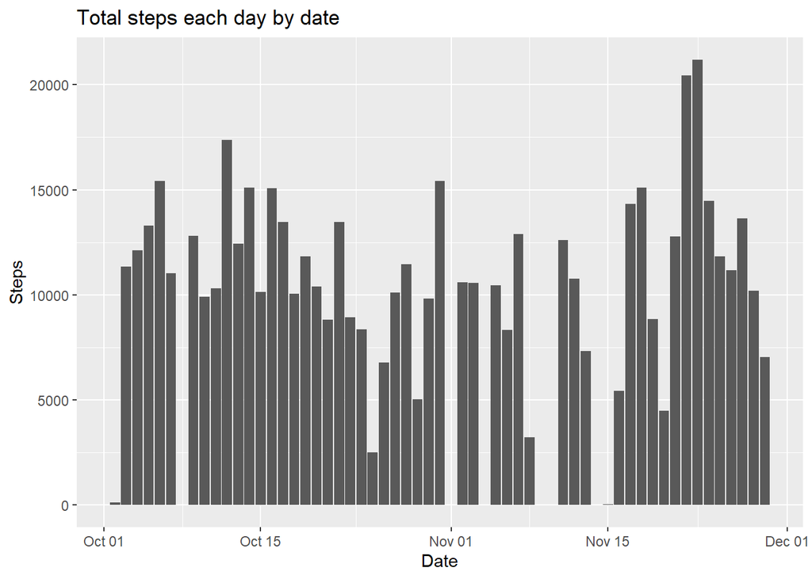

```r
g2 <- qplot(stepseachday$steps, geom = "histogram", binwidth = 5000,xlab = "Steps",
            ylab = "Frequency", main = "Total Steps")
print(g1)
```

Saving both the plots in a png file, ‘plot1.png’. The png file is saved in the working directory.

```r
ggsave("plot1.png", arrangeGrob(g1,g2))
```

Mean of number of steps taken each day is calculated using mean function and stored in variable meanstepseachday.

```r
meanstepseachday <- mean(stepseachday$steps)
print(meanstepseachday)
```

```
## [1] 10766.19
```

```r
medianstepseachday <- mean(stepseachday$steps)
print(medianstepseachday)
```

```
## [1] 10766.19
```

## Time series plot of the average number of steps taken

Subsetting the original dataset to dataset only containing average steps taken each interval and storing it in a variable ‘stepseachinterval’

```r
stepseachinterval <- aggregate(steps ~ interval, df, mean, na.rm = TRUE)
```

Plotting the time series plot between average steps vs interval using ggplot function and saving the plot in png file, “plot2.png”.

```r
png("plot2.png")

plot2 <- ggplot(stepseachinterval, aes(interval, steps)) + geom_line() +
         ggtitle("Daily Activity Pattern")

print(plot2)

dev.off()
```

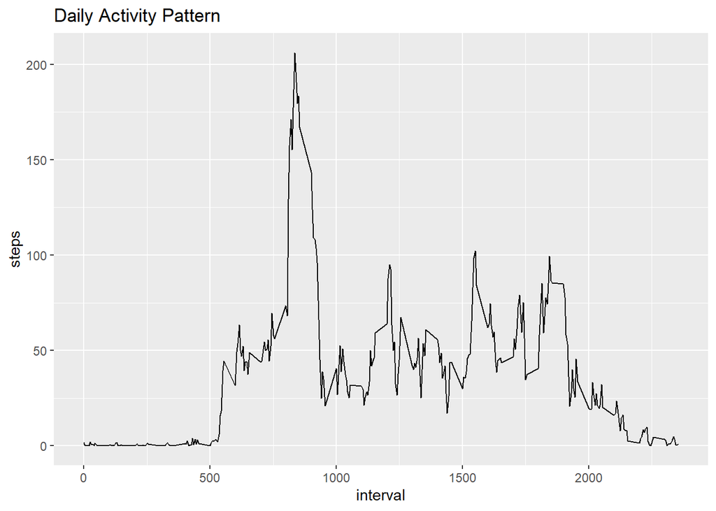

```r
print(plot2)
```

## The 5-minute interval that, on average, contains the maximum number of steps

The 5-minute time interval with maximum number of steps averaged across all days is calculated using which.max() function.

```r
stepseachinterval$interval[which.max(stepseachinterval$steps)]
```

```
## [1] 835
```

## Code to describe and show a strategy for imputing missing data

First seeing how many missing values are there in each column.

```r
sum(is.na(df$day))
```

```
## [1] 0
```

```r
sum(is.na(df$interval))
```

```
## [1] 0
```

```r
sum(is.na(df$steps))
```

```
## [1] 2304
```

As seen, only column steps contain the missing values. As given in the question, there are many methods which are also listed to impute these missing values. However, for the purpose of simplicity, imputing the missing values by the average of average steps taken in each day.

```r
nasteps <- mean(with(df, tapply(steps, date, mean, na.rm = TRUE)), na.rm = TRUE)
df[is.na(df$steps),1] <- nasteps
```

Cross checking if there are many missing values now in data.

```r
sum(is.na(df$day))
```

```
## [1] 0
```

```r
sum(is.na(df$interval))
```

```
## [1] 0
```

```r
sum(is.na(df$steps))
```

```
## [1] 0
```